# Introduction to R

Victor Ordu

# Introduction

## Prerequisites

To participate effectively in this course, you will need to fufil the following requirements: a. You should be able to see at a computer screen b. You should be able to hit the keys of a computer keyboard c. You must be willing and eager to learn d. You need to be adventurous (and a little courage will help, too!)

## What is R?

R is a programming language for statistical computing. It developed in the 1980s, by two researchers from the University of Auckland, New zealand, for the purpose of running statistical analyses amongst other capabilities. Their names are Robert Gentleman and Ross Ithaka. R has grown to become one of the most widely used tools by data scientists and its popularity is on the rise.

Your first encounter with R may appear quite intimidating, especially if you don’t have any experience with using computer languages. However, experience has shown that, being a relatively high-level language, users with little or not understanding of computer architecture can developing a working knowledge that is sufficient for carrying out data-related operations and tasks. One of the aims of this manual is to have the R novice up and running in no time.

Now, let’s jump in immediately. Consider these 2 lines of code:

```r
x <- 1:10
x
```

We have created an “object” in R called x. The arrow-like symbol `<-` is called the “assignment key” and the expression on the right hand side of this symbol means " from 1 to 10“. When you execute or”run" the second line of this code, the R console print out the numbers 1 through 10.

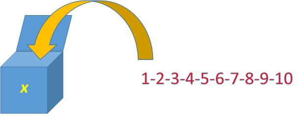

In this particular example, the object “x” is called a vector (in R, we have differenct types of objects). So, in essence, we now have an R object labelled ‘x’, and x contains the numbers 1 - 10.All of this will be explained as we proceed. (Note that we generated the assignment key by typing the “less than” (<) key followed by the “dash” (-) key.)

## The pros and cons of using R

There are several advantages to using R, and as anything in life, there are some disadvantages.

Advantages: a. It is free b. It is easy to download and install c. It has a vibrant community d. It produces publication grade graphics e. It is easy to learn f. It is highly extensible. g. It ensure reproducibility of results. h. It encourages transparency in methodology.

Disadvantages: a. It is difficult to master. b. The language can be quirky and is not very intuitive.

## Download and installation of R

Downloading R is very easy. To get the latest version, visit www.r-project.org. Click on the “Download” link and you will be taken to the appropriate page. Download the latest version. When installing, you may be given the option of installing 32-bit and 64-bit versions. It is recommended that you install the 64-bit version. If you’re not familiar with loading programs from the directory, make sure you check the box “Create Desktop icon”.

## The R Console

To open your R installationWhen you can double-click your R Desktop icaon. You will encounter the R console. If you are not familiar with command line operations, don’t panic.

When you write a piece of code, R will read the instruction you have passed to it just they way we do - from left to right, top to bottom (yeah, we know that some people read from right to left, but never mind that). Now you’re encouraged to create the object “x” as exemplified above. Do it now. Type each line of the code into the console and hit “Enter” after each line. Note that the second line has only on character.

```r
    # Create an object x
  x <- 1:10
    x
```

```
##  [1]  1  2  3  4  5  6  7  8  9 10
```

Examine your output in the console. What do you see? Note that though there are 3 lines of script here, only 2 of these lines are actual R code. The first line that starts with “#” is a comment line and will not be executed by R. It is good practice to add comments to code as this makes for readability and helps others to understand you approached your task.

## Objects

The operation you carried out in the previous section is very typical of a coding exercise in R. R is an object-oriented language and the creation of objects is central to everything you will be doing in R. R objects can be classified according to their homogeneity or their dimensionality. Homogenous objects have contain values of the same type e.g. numbers, while heterogenous objects can contain different types of values e.g. numbers and characters. In terms of dimensionality, some objects are one-dimensional, while others are multi-dimensional. This will be more clearly explained in the next section. Quiz: How would you describe the object “x” you created? Is is homogenous? Is it multi-dimensional?

## Vectors

Vectors are R’s building blocks. You can create vectors and you can also import them from other users. They are the fundamental data structure of R. There are four (4) main types of vectors that we will be using to carry out most R operations. They are: a. Integer b. Character c. Logical d. Double

You are now going to create these vectors. Run the following lines of code:

```r
age <- 50
sex <- "female"
employed <- TRUE
height <- 1.32

# output of the operations
age
```

```
## [1] 50
```

```r
sex
```

```
## [1] "female"
```

```r
employed
```

```
## [1] TRUE
```

```r
height
```

```
## [1] 1.32
```

```r
age <- c(50, 23, 45, 38, 43, 23)
age
```

```
## [1] 50 23 45 38 43 23
```

```r
sex <- c("male", "female", "male", "female", "female", "female")
sex
```

```
## [1] "male"   "female" "male"   "female" "female" "female"
```

```r
employed <- c(TRUE, TRUE, TRUE, FALSE, TRUE, FALSE)
employed
```

```
## [1]  TRUE  TRUE  TRUE FALSE  TRUE FALSE
```

```r
height <- c(1.54, 1.80, 1.96, 1.22, 1.32, 1.39)
height
```

```
## [1] 1.54 1.80 1.96 1.22 1.32 1.39
```

Finally, we can create NULL vectors

```r
first.name <- c("Eze", "Hassan", "Modupe")
first.name
```

```
## [1] "Eze"    "Hassan" "Modupe"
```

```r
first.name <- NULL
first.name
```

Before concluding this chapter, it is important to point out that R is case-sensitive, so care has to be taken as it may or may not return an error and if the latter occurs, you will have unexpected results that would affect your entire analysis.

```r
country <- c("Nigeria", "United Kingdom", "Paraguay", "Japan", "Germany", "South Africa", "Jamaica")
# length(Country) # error

identical("Queen", "queen")
```

```
## [1] FALSE
```

```
 Quiz: Try creating a vector of length > 1 without using the c() function. What happened? Try again using c(). What happened this time?
 Look at the integer and double vector. what are their differences and similarities?
```

## Workspace

At this stage, most of the operations you will be carrying out in R are done in what is called a “workspace”. You may liken this to a desk or table on which you have laid out items you want to work with. The objects you create will be places on this virtual desk for you to work with as you please. So far, the objects that you have created are there. To view them, run

```r
ls() # lists all the objects in the workspace
```

```
## [1] "age"        "country"    "employed"   "first.name" "height"
## [6] "sex"        "x"
```

You can now see, the objects you created.

To remove an object from the workspace

```r
rm(x) # removing x from the workspace
ls()
```

```
## [1] "age"        "country"    "employed"   "first.name" "height"
## [6] "sex"
```

To clear the workspace, we will use a combination of the rm() and ls() functions.

```r
rm(list = ls()) # clear the workspace
ls()
```

```
## character(0)
```

```r
# workspace now empty
```

Removing an object is not the same thing as creating an empty vector.

```r
home <- c("duplex", "bungalow", "hut")
home
```

```
## [1] "duplex"   "bungalow" "hut"
```

```r
ls() # 'home' is in the workspace
```

```
## [1] "home"
```

```r
home <- NULL
home
```

```r
ls() # 'home' is still in the workspace
```

```
## [1] "home"
```

```r
rm(home)
ls() # 'home' is no longer in the workspace
```

```
## character(0)
```

Note that there is no “undo” function (if there is I don’t know, but with R you can never tell) and there is no way to return our items to the workspace other than to re-run the code. To help you do this, R keeps are record of the history of the code you’ve passed to the console that can be easily accessed via the up-arrow key. If you call the history() function, a list of your recent commands will be presented for you to use. Try it out now.

Finally, R has given you the option of creating scripts of your code that you can put into a text file and save on your devices (go to File > New Script). When you finish working, save the file to your working directory.

The working directory is where all the data from your R operations will be stored. It good practice to use different working directories for different R operations. For instance, if you are conducting analyses on infant formula feeding, it would be wise for you to use different working directory from the one you used to analyze data on car emissions. To know which directory you are working in run

```r
getwd()
```

```
## [1] "C:/Users/BRIAN/Documents/2-Biz/GHMC/R Training/IntroR"
```

To set the working directory we use the command setwd()

```r
setwd("C:/Users/BRIAN/Documents/2-Biz/GHMC/R Training")
getwd()
```

```
## [1] "C:/Users/BRIAN/Documents/2-Biz/GHMC/R Training"
```

```r
dir() # lists all the folders and files in the directory
```

```
##  [1] "IntroR"
##  [2] "Manual.html"
##  [3] "Manual.Rmd"
##  [4] "National Health Account Data_1998-2002.xls"
##  [5] "R Training.Rproj"
##  [6] "README.md"
##  [7] "SampleRplot(2).png"
##  [8] "SampleRplot.jpeg"
##  [9] "script.R"
## [10] "whostat2005_healthsystems.xls"
```

Exercise: create a folder on your computer for your R Training sessions (do this outside of R!). Next, return to R and set the working directory of your R session to this newly created directory.

## Getting help

When you are working with R, you’re going to need a lot of help as you conduct your analyses. This is not because you don’t know what your doing, but that’s just the way it works with R. Even the most experienced users of R use these features on a regular basis in order to get the most out of it. Like we said earlier, R is difficult to master. This is partly because of its extensiblity and constant change it undergoes (the R Consortium releases major updates every 6 months!).

To get help on any R function, do the following

```r
# use ?function() to read the R documentation e.g.
?getwd()
```

```
## starting httpd help server ...
```

```
##  done
```

```r
# to see some examples of code
example("getwd")
```

```
##
## getwd> (WD <- getwd())
## [1] "C:/Users/BRIAN/Documents/2-Biz/GHMC/R Training/IntroR"
##
## getwd> if (!is.null(WD)) setwd(WD)
```

Sometimes, understanding the R documentation can be a bit challenging for newcomers. However, there are some useful sites you can visit to get quick tips on how to carry out certain operations in R e.g. Quick R. The official FAQs of the R Consortium are also useful for technical information. Sites like Stackoverflow have so many R questions already answered and you can also ask your own questions as well. One great thing about the R community is that you will find them eager to assist. If you’re on Twitter, use the hashtag #rstats to find tweets about R and find a few people to follow such as @hadleywickham and @jennybryan.

As you begin to work with R, you will discover, that there is really no “one way” of doing anything. Rather the application is so robust that there are several ways of approaching a challenge and arriving at similar or even the same conclusion. Thus, this training is not meant to lock you down in the author’s ways, but to give you a launching pad for you to explore for yourselves. As we go further into the meat of the matter, you are encouraged to play around with the code and make as many mistakes as possible, for that is how you can quickly learn what works and what doesn’t.

Welcome to the wonderful world of R!

# Two-dimensional data structures

Most of you are probably used to seeing your data in a 2-dimensional format, you know, something that looks like a table. By 2-dimensional, we mean that each data element has two reference points, and they are typically represented in a row-column format. Well, data can actually come in different forms, just like the vectors we described in the last section. But because 2-dimenstional objects are the most common, we are going to start from there, so that you can quickly get to see how R works in practice. We will go back to the other data formats later.

So, in R, you will be encountering 2 types of 2-dimensional objects - matrices and dataframes. Before we proceed, I want to alert you that occasionally you will see some more complex code - don’t be alarmed or intimidated. The secret to learning code is to never, ever be scared if you see something new. Besides, we will use comments, as usual, to make our code more readable and easy to understand.

## The Matrix

To create one we call the matrix() function

```r
# Create a matrix and assign it the label 'mat'
mat <- matrix(1:10)
mat
```

```
##       [,1]
##  [1,]    1
##  [2,]    2
##  [3,]    3
##  [4,]    4
##  [5,]    5
##  [6,]    6
##  [7,]    7
##  [8,]    8
##  [9,]    9
## [10,]   10
```

We will now pass other arguments to this function to modify ‘mat’. Please open the R documentation on this function to see the different arguments that can be used. Run this code: ?matrix() to open the help page.

```r
mat2 <- matrix(1:12, nrow = 2) # matrix with 2 rows
mat2
```

```
##      [,1] [,2] [,3] [,4] [,5] [,6]
## [1,]    1    3    5    7    9   11
## [2,]    2    4    6    8   10   12
```

```r
mat3 <- matrix(1:12, nrow = 3) # matrix with 3 rows
mat3
```

```
##      [,1] [,2] [,3] [,4]
## [1,]    1    4    7   10
## [2,]    2    5    8   11
## [3,]    3    6    9   12
```

By default, the matrix is created in a columnwise fashion. You can see this by the order of the numbers in the matrix and confirm it from the default arguments in the help page (byrow = FALSE). Now let’s tweak this a bit so you understand it better. Remember to be advenurous and experiment. R won’t bite you if you mess up!

```r
mat3_rowwise <- matrix(1:12, nrow = 3, byrow = TRUE)
mat3_rowwise
```

```
##      [,1] [,2] [,3] [,4]
## [1,]    1    2    3    4
## [2,]    5    6    7    8
## [3,]    9   10   11   12
```

```r
mat3         # compare them
```

```
##      [,1] [,2] [,3] [,4]
## [1,]    1    4    7   10
## [2,]    2    5    8   11
## [3,]    3    6    9   12
```

You can also create matrices using the other types of data elements you used in making atomic vectors in the last section.

```r
mat_char <- matrix(rep(c("jane", "john", "bob", "emeka", "zainab"),
                       times = 6)) # we called 3 functions - matrix(), rep() & c() to create a matrix by repeating each of the characters 6 times for a total of 30
mat_char
```

```
##       [,1]
##  [1,] "jane"
##  [2,] "john"
##  [3,] "bob"
##  [4,] "emeka"
##  [5,] "zainab"
##  [6,] "jane"
##  [7,] "john"
##  [8,] "bob"
##  [9,] "emeka"
## [10,] "zainab"
## [11,] "jane"
## [12,] "john"
## [13,] "bob"
## [14,] "emeka"
```

[output cut: 16 more lines]

```r
mat_char <- matrix(mat_char, nrow = 3)
mat_char
```

```
##      [,1]   [,2]     [,3]    [,4]     [,5]     [,6]   [,7]     [,8]
## [1,] "jane" "emeka"  "john"  "zainab" "bob"    "jane" "emeka"  "john"
## [2,] "john" "zainab" "bob"   "jane"   "emeka"  "john" "zainab" "bob"
## [3,] "bob"  "jane"   "emeka" "john"   "zainab" "bob"  "jane"   "emeka"
##      [,9]     [,10]
## [1,] "zainab" "bob"
## [2,] "jane"   "emeka"
## [3,] "john"   "zainab"
```

```r
str(mat_char) # this is a character matrix with 3 rows and 10 columns
```

```
##  chr [1:3, 1:10] "jane" "john" "bob" "emeka" "zainab" ...
```

There is one thing to note about matrices. Just like atomic vectors, they can contain only one type of element - integer, double, character or logical. This is how they differ from dataframes, which can contain different data types in the same object. We will discuss those in the next section.

[output not shown]